# Replicating Currency Hedging Analysis

André le Roux

November 2024

### Abstract

In this report I will recreate the graphic and table found in the associated study as well as adding additional context and evidence as to why systematic currency hedging can have a negative impact on performance.

# Data

The data used in this report consists of a file with the returns of local and foreign assets from which to we can construct a Local/Global, Equity/Bond portfolio so as to determine the impact of currency hedging on portfolio performance. In order to estimate the impact of the exchange rates the data on the monthly USD/ZAR exchange rate is also used.

# Analysis

The first step in the analysis is to recreate the graphic from the original article discussing the impact of currency hedging on portfolio performance. This is done by creating a portfolio with a 60 / 40 (Equity/Bond) split and a 70 / 30 (Local/Global) split and comparing the hedged versus unhedged scenearios for this portfolio.

##### Figure 1:

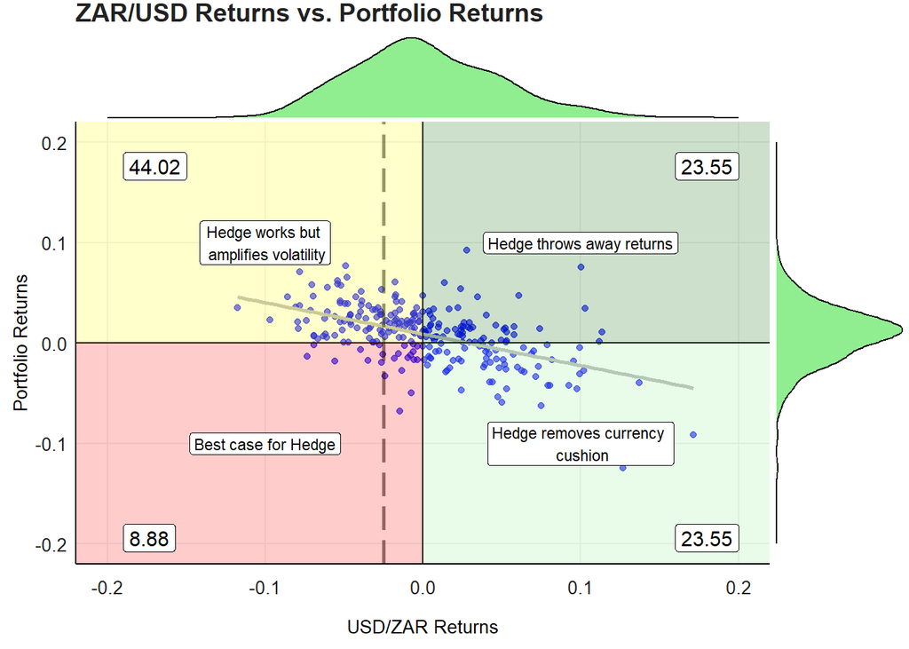

From *figure 1* we can see that the percentage of data that falls into the quadrant where currency hedging has a purely positive effect is only 8.88%, this further decreases when you take into consideration the costs associated with hedging, represented by the dashed line. There is a clear negative correlation between portfolio returns and the USD/ZAR exchange rate, this suggest that the removal of the exchange rate risk from the portfolio would in fact increase the volatility of the portfolio.

Next I recreate and expand the table found in the article to show different metrics of the hedged-, unhedged portfolio and a fully hedged Global portfolio.

##### Table 1:

Table 1: USD-ZAR Fund Performance

|  | Internation Hedged | Hedged Portfolio | Unhedged Portfolio |
| --- | --- | --- | --- |
| Annualized Return | 0.0383 | 0.0794 | 0.1101 |
| Annualized Standard Deviation | 0.1058 | 0.0983 | 0.0841 |
| Average Drawdown | 0.0694 | 0.0444 | 0.0281 |
| Adjusted Sharpe ratio (Risk free = 0) | 0.3444 | 0.7038 | 1.1281 |

Note: Own Calculations

The findings from *table 1* corroborate the findings of the article. That when fees are taken into account the hedged funds perform considerably worse than the unhedged fund on all metrics that were calculated. Thus, hedging currencies, especially systematically, decreases returns and increases volatility.

Next I estimate the rolling 5 year annualised standard deviation of the returns series of the hedged and unhedged portfolio, this gives us a glimpse of the long-run volatility of the two portfolios and how they compare.

##### Figure 2:

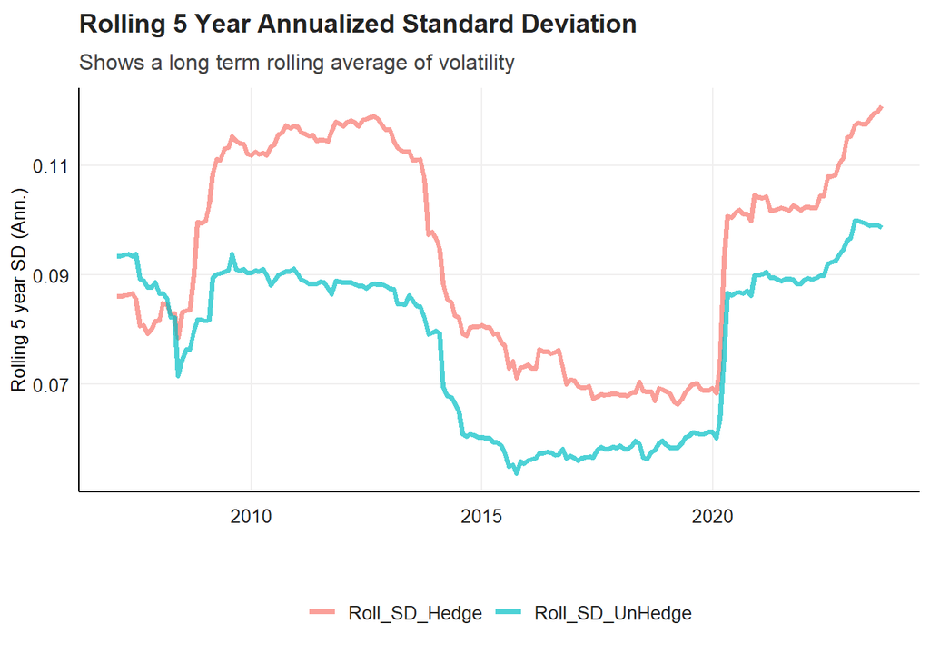

As can be seen in *figure 2*, during the majority of the period the unhedged portfolio has lower volatility than the hedged portfolio, there could be arguments made for situational and shorter-term hedging, as can be seen in the earliest parts of *figure 2*, but systematic hedging is not plausible.

# Conclusion

The results I have found correspond to the results from the article, suggesting that the systematic hedging of the Rand will have a negative impact on portfolio performance. Although a possibility for short-term strategies, long-term hedging should be avoided.